# **Unit 3 Assignment: Understanding the HR Diagram**

Stars are the fundamental building blocks of the universe, serving as the engines that fuel galaxies and the laboratories where elements are forged. From the Sun, our closest star, to the distant giants that illuminate the night sky, stars come in a wide variety of sizes, temperatures, and luminosities. In this assignment, you will become a stellar detective, using the tools and concepts you’ve learned to unravel the mysteries of a select group of stars.

### **Key Concepts and Formulas**

1. **Luminosity and Temperature:** The luminosity of a star is the total energy it emits per second. The Stefan-Boltzmann law relates a star’s luminosity (\(L\)) to its surface area and temperature:

   \[ L = 4\pi R^2 \sigma T^4 \]

   Where:
   - \(L\) is the luminosity,
   - \(R\) is the radius of the star,
   - \(T\) is the surface temperature,
   - \(\sigma\) is the Stefan-Boltzmann constant.

   This equation shows that a star’s luminosity depends on both its size and temperature. Hotter and larger stars emit more energy, making them more luminous.
2. **The Inverse Square Law and Apparent Brightness:** The apparent brightness or flux (\(F\)) of a star as seen from Earth is related to its luminosity and distance (\(r\)) from Earth:

   \[ F = \frac{L}{4\pi R^2} \]

   Distant stars appear dimmer than those that are closer, even if they have the same luminosity. By knowing a star’s apparent brightness and distance, you can calculate its true luminosity.
3. **Stellar Evolution and the HR Diagram:** Stars evolve over time, following a life cycle that depends on their mass. The Hertzsprung-Russell (HR) diagram plots stars according to their luminosity and temperature, revealing patterns that correspond to different stages of stellar evolution. Most stars spend the majority of their lives on the **main sequence**, fusing hydrogen into helium in their cores.
4. **Mass-Luminosity Relationship for Main-Sequence Stars:** The luminosity of main-sequence stars is approximately proportional to the mass raised to the power of 3.5:

   \[ \frac{L}{L_\odot} = \left( \frac{M}{M_\odot} \right)^{3.5} \]

   This equation shows that more massive stars are more luminous but have shorter lifespans.
5. **Nucleosynthesis and Energy Production:** Stars generate energy through nuclear fusion, where lighter elements, like hydrogen, are fused into heavier elements, like helium, in the core. As stars evolve, they can fuse heavier elements, creating the elements found throughout the universe.

### **Part 1: Data Analysis and HR Diagram Plotting**

| Star # | Temperature (K) | Luminosity (\(\frac{L}{L_\odot}\)) | Radius (\(\frac{R}{R_\odot}\)) | Absolute Magnitude (\(M_v\)) | Star Type | Spectral Class |
| --- | --- | --- | --- | --- | --- | --- |
| 1 | 9030 | 45.0 | 2.63 | 1.450 | 2 | A |
| 2 | 7720 | 7.92 | 1.34 | 2.440 | 2 | F |
| 3 | 16500 | 0.013 | 0.014 | 11.890 | 1 | B |
| 4 | 14245 | 231000 | 42 | -6.120 | 3 | O |
| 5 | 3575 | 123000 | 45 | -6.780 | 3 | M |
| 6 | 11900 | 0.00067 | 0.00898 | 11.380 | 1 | B |
| 7 | 16390 | 1278 | 5.68 | -3.320 | 2 | B |
| 8 | 39000 | 204000 | 10.6 | -4.700 | 2 | O |
| 9 | 5300 | 0.59 | 0.91 | 5.490 | 2 | F |
| 10 | 19400 | 10920 | 6.03 | -3.080 | 2 | B |
| 11 | 5936 | 1.357 | 1.106 | 4.460 | 2 | F |
| 12 | 18290 | 0.0013 | 0.00934 | 12.780 | 1 | B |
| 13 | 30000 | 28840 | 6.3 | -4.200 | 2 | B |
| 14 | 12010 | 0.00078 | 0.00920 | 12.130 | 1 | B |
| 15 | 9373 | 424520 | 24 | -5.990 | 3 | O |
| 16 | 15680 | 0.00122 | 0.01140 | 11.920 | 1 | B |
| 17 | 8250 | 9.25 | 1.93 | -0.980 | 2 | F |
| 18 | 25000 | 0.056 | 0.00840 | 10.580 | 1 | B |
| 19 | 17383 | 342900 | 30 | -6.090 | 3 | O |
| 20 | 34190 | 198200 | 6.390 | -4.570 | 2 | O |
| 21 | 8924 | 0.00028 | 0.00879 | 14.870 | 1 | A |
| 22 | 11250 | 672 | 6.98 | -2.300 | 2 | A |
| 23 | 10574 | 0.00014 | 0.00920 | 12.020 | 1 | F |
| 24 | 29560 | 188000 | 6.02 | -4.010 | 2 | B |
| 25 | 4077 | 0.085 | 0.79500 | 6.228 | 2 | K |

1. **Plot the Stars on the HR Diagram:**
   - Use the provided data to plot each star on an HR diagram. The x-axis represents temperature (logarithmic scale), and the y-axis represents luminosity (logarithmic scale).
   - Use the luminosity and temperature to determine the position of each star on the diagram.

[figure not shown]

2. **Identify Star Types:**
   - Each star is categorized as Type 1, 2, or 3. Use the HR diagram, the stars’ properties, and your knowledge on stellar evolution to determine what these types represent.
3. **Explain Star Classification:**
   - After plotting the stars and identifying their types, write a brief explanation of how you determined the classification for each star type. Reference the position of each star on the HR diagram and connect their properties to stellar evolution.

### **Part 2: Conceptual Questions**

1. **Evolutionary Paths:**
   - Consider Star #11 from the table. Explain its likely evolutionary path. Justify your prediction based on the star's mass, luminosity, and evolutionary stage.

> **Hint:** For main-sequence stars, luminosity is related to mass by the formula \(\frac{L}{L_\odot} = \left( \frac{M}{M_\odot} \right)^{3.5}\).
2. **Energy Production and Fusion:**
   - Describe the energy production process (i.e. thespecific fusion processes) occurring inside stars at different stages of their life cycles.
3. **Fusion and Luminosity:**
   - How does the fusion process inside a star relate to its luminosity and temperature? Why do stars become more luminous as they evolve off the main sequence?
4. **Impact of Distance on Brightness:**
   - Explain how distance affects the apparent brightness of stars. How can two stars with similar luminosities appear drastically different in brightness from Earth due to their distances?
5. **Connecting Mass, Luminosity, and Lifespan:**
   - Reflect on the relationship between a star’s mass, luminosity, and lifespan. Why do stars with higher masses have shorter lifespans despite having more fuel?

   > **Hint:**

   > Recall that the luminosity is the rate of energy output and \(L \propto M^{3.5}\)

### **Part 3: Calculation Questions**

1. Star 5 (M-type star) and Star 7 (B-type star) have very different temperatures and radii. Star 5 is much cooler but significantly larger, while Star 7 is much hotter but smaller. Calculate the surface flux (energy per square meter per second) for both stars using the Stefan-Boltzmann law: \(F = \sigma T^4\), where \(T\) is the temperature and \(\sigma = 5.67 \times 10^{-8}\) W/m\(^2\)/K\(^4\) is the Stefan-Boltzmann constant. Use the calculated flux and the given radii to explain how each star achieves its luminosity. Does the difference in temperature fully account for the difference in luminosity, or does the size of the star play a crucial role?
2. **Estimating the Lifetime of Star 7:**
- In lesson 3.3, we found that the mass loss of one proton-proton (p-p) chain reaction is 0.02862 u, which represents about 0.71% of the initial mass. Therefore, when 1 kilogram of hydrogen is converted into helium, approximately 0.0071 kilograms of mass is converted into energy.
- Models of massive stars like Star 7 indicate that only about 10% of the total hydrogen in the star will participate in nuclear reactions, as it is only the hydrogen in the central regions that is at a high enough temperature.
- Use this information to estimate the lifetime of Star 7.

**Given:**

- **Luminosity of Star 7**: \(1,278 L_\odot\).
- **Luminosity of the Sun**: \(L_\odot = 3.8 \times 10^{26}\) watts.
- **Mass of the Sun**: \(M_\odot = 2 \times 10^{30}\) kg.

  i . **Calculate the mass of Star 7** using the mass-luminosity relationship: \[ \frac{L}{L_\odot} = \left(\frac{M}{M_\odot}\right)^{3.5} \] Solve for \(M\) in terms of \(L\) and \(L_\odot\), and then calculate the mass of Star 7 in kilograms.

  ii . **Determine the total energy available from hydrogen fusion** in Star 7’s core. Assume that 10% of Star 7’s mass participates in nuclear fusion. Calculate the total energy released from this mass of hydrogen using the fact that 0.0071 kg of mass is converted into energy for every 1 kg of hydrogen.

  > **Hint:**

  > \(E = \Delta m \cdot c^2\)

  iii. **Estimate the lifetime of Star 7**. Use the total energy available from fusion and the luminosity of Star 7 to estimate the lifetime in seconds, then convert this value to years.

> **Hint:**

> Think about the units: luminosity is energy per unit time (1 watt = 1 Joule/s) and you want to get units of time!
3. **Radius of Betelgeuse:**
   - Given the temperature (3400 K) and luminosity (13,200 \(L_\odot\)) of Betelgeuse, calculate its radius. Compare it to the Sun’s radius, and discuss what this tells us about Betelgeuse's evolutionary stage.

```python
import numpy as np
import pandas as pd
import matplotlib.pyplot as plt
import seaborn as sns
df_ori=pd.read_csv('6 class csv.csv')
df=df_ori.copy()
df.head()
```

|  | Temperature (K) | Luminosity(L/Lo) | Radius(R/Ro) | Absolute magnitude(Mv) | Star type | Star color | Spectral Class |
| --- | --- | --- | --- | --- | --- | --- | --- |
| 0 | 3068 | 0.002400 | 0.1700 | 16.12 | 0 | Red | M |
| 1 | 3042 | 0.000500 | 0.1542 | 16.60 | 0 | Red | M |
| 2 | 2600 | 0.000300 | 0.1020 | 18.70 | 0 | Red | M |
| 3 | 2800 | 0.000200 | 0.1600 | 16.65 | 0 | Red | M |
| 4 | 1939 | 0.000138 | 0.1030 | 20.06 | 0 | Red | M |

Brown Dwarf -> Star Type = 0

Red Dwarf -> Star Type = 1

White Dwarf-> Star Type = 2

Main Sequence -> Star Type = 3

Supergiant -> Star Type = 4

Hypergiant -> Star Type = 5

```python
# Remove entries with Star type 0, 1, or 5
df = df[~df['Star type'].isin([0, 1, 5])]
```

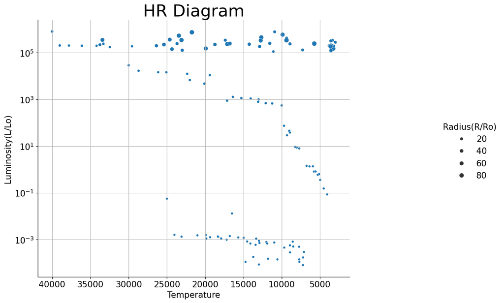

```python
plt.rcParams['font.size']=15
hr=sns.relplot(x='Temperature (K)',y='Luminosity(L/Lo)',size='Radius(R/Ro)',data=df)
hr.fig.set_figwidth(16)
hr.fig.set_figheight(8)

hr.ax.set(yscale='log')


plt.xlabel('Temperature')
plt.ylabel('Luminosity(L/Lo)')
plt.gca().invert_xaxis()
#plt.gca().invert_yaxis()
plt.grid(True)
plt.title('HR Diagram',fontsize=30)
```

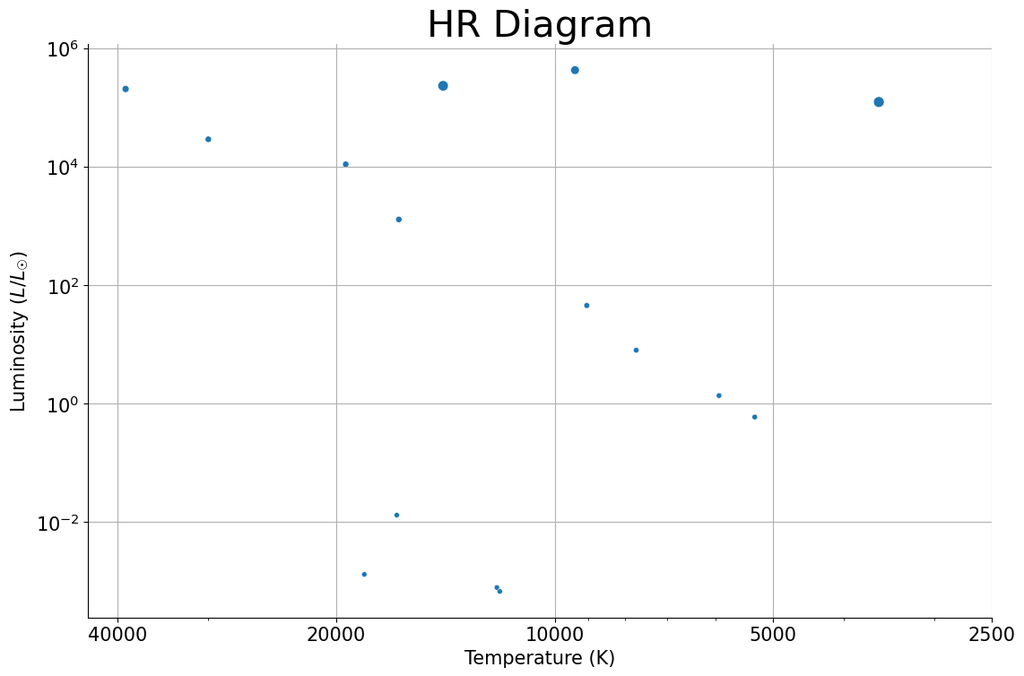

```python
# Select a random sample of 25 entries from the DataFrame
df_sample = df.sample(n=15, random_state=42)

plt.rcParams['font.size'] = 15
hr = sns.relplot(x='Temperature (K)', y='Luminosity(L/Lo)', size='Radius(R/Ro)', data=df_sample, legend=False)
hr.fig.set_figwidth(16)
hr.fig.set_figheight(8)

hr.ax.set(yscale='log')
hr.ax.set(xscale='log')

# Set custom x-ticks
hr.ax.set_xticks([2500, 5000, 10000, 20000,40000])
hr.ax.set_xticklabels([2500, 5000, 10000, 20000,40000])

plt.xlabel('Temperature (K)')
plt.ylabel('Luminosity (\(L/L_☉\))')
plt.gca().invert_xaxis()
plt.grid(True)
plt.title('HR Diagram', fontsize=30)
plt.savefig('figures/HR_assignment.png',
            facecolor='white', bbox_inches='tight', pad_inches=0.05)
```